# L01 Data Visualization

Data Science 1 with R (STAT 301-1)

INSTRUCTIONS

**Warning**

Make sure your solutions are clearly indicated and that your document is neatly formatted.

**TipGithub Repo Link**

A link to your GitHub repo should be placed at the top your submitted html.

## Overview

The goal of this lab is to start building the skills to explore data through visualization using the `ggplot2` package in R (member of the `tidyverse`). Students will also learn to access and utilize R documentation.

## Load packages

You should always begin by loading all necessary packages towards the beginning of your document.

```r
# Loading package(s)
```

## Datasets

This lab utilizes the `mpg` and `diamonds` datasets. Both come with `ggplot2` and their documentation/codebooks can be accessed with `?mpg` and `?diamonds`, provided you have installed and loaded `ggplot2` to your current R session. The case study utilizes `tinder_data.csv` located in your `data` folder. The following lines of code read in tinder data and its codebook. We will learn more about reading in data in Chapter 7.

```r
# read in data
tinder_data <- read_csv("data/tinder_data.csv")
tinder_data_codebook <- read_csv("data/tinder_data_codebook.csv")
```

## Exercises

### Exercise 1

There are 3 particularly important components to our template for building a graphic with `ggplot2`. They are `<DATA>`, `<GEOM_FUNCTION>`, and `<MAPPINGS>`. The importance of `<DATA>` is obvious. `<GEOM_FUNCTION>` is referring to the selection of a **geom**. `<MAPPINGS>`, specifically `aes(<MAPPINGS>)`, is referring to the process of defining **aesthetic mappings**.

- What is a **geom**?
- What is an **aesthetic mapping**?

### Exercise 2

Construct a scatterplot of `hwy` versus `cty` using the `mpg` dataset. What is the problem with this plot? How could you improve it?

### Exercise 3

Construct a scatterplot of `hwy` versus `cty` with the color of the points mapped to `drv`.

Now construct second scatterplot of `hwy` versus `cty`, but this time set the color of the points to your favorite color[^1] and `facet` by `drv`. Read `?facet_wrap` and adjust the `ncol` and `scales` as necessary.

<sup>1</sup> Try typing `colors()` in the console to get a list of named colors.

What are the advantages to using faceting instead of the color aesthetic? What are the disadvantages? How might the balance change if you had a larger dataset?

### Exercise 4

Construct a scatterplot of `hwy` vs `cty` with a third numerical variable being mapped to `color`; then to `size`; then to `shape`.

How do the aesthetics behave differently for categorical versus numerical variables? In other words, which variable types (numeric/categorical) are appropriate to match to which aesthetics (`size`/`shape`/`color`)?

### Exercise 5

Construct a histogram of the `carat` variable in the `diamonds` dataset. Adjust the `bins` to an appropriate value, add a `title`, remove the axis label that says `count`, and add a `caption`: `"Source: ggplot2 package"`.

### Exercise 6

Construct 2 appropriate graphics to show the relationship between `carat` and `cut`.

### Exercise 7

Construct a barplot of `cut` and include `fill = carat > 0.7` as an aesthetic mapping. Describe what the mapping fill to `carat > 0.7` does.

### Exercise 8

When would you use `facet_grid()` versus `facet_wrap()`? When using `facet_grid()` it is suggested that you put the variable with more unique levels in the columns. Why do you think that this practice is suggested?

## Case Study

**Note**

The case study portion for labs is different than the exercises portion. The core learning objective for them is to see if you can bring tools together and produce work meant for more general consumption. That is, can you bring everything together and answer a question clearly and concisely with supporting evidence.

Congratulations, you just landed your first job as a data analyst for Tinder! The dataset is stored in the `data` folder called `tinder_data`. A codebook, `tinder_data_codebook.csv`, provides a description of each of the variable names. This has been read in for you at the top of the document. We will learn more about importing data later in the quarter.

**Your first assignment is to determine if there is a relationship between messages sent and messages received and how this differs based on user gender.** Your boss has asked for a one paragraph summary with graphics to support your conclusions. Your boss wants all graphics *saved* into a folder named `plots`. Hint: `ggsave()`.

Since this is your first project as a data analyst you have been provided some tips and considerations for getting started:

- When approaching a research question it is important to use univariate, bivariate, and multivariate analysis (depending on the problem) to get a better understanding of your data and also identify any potential problems.
- How might the distribution of your variables impact your conclusions? Outliers? Weird values? Imbalanced classes?
- How might `coord_fixed()` and `geom_abline()` improve a graphic?
- Feel free to be creative! It is your job to answer this question and provide conclusions that you find reasonable given the information you have.

This dataset was provided by [Swipestats.io](https://www.swipestats.io/).

**Warning**

The final product is meant for your boss and needs to be presented as such. A well written paragraph and supporting graph(s). There should be no visible or accessible code — your boss does not care about it. Your graphics should be polished (appropriate titles and such).

## Graduate Challenge

**Important**

Graduate students are required to complete this challenge. **It is optional for undergraduate students.**

Recreate the following graphic:

- `alpha = 0.25`
- theme is with Google Docs Chart from [ggthemes package](https://jrnold.github.io/ggthemes/reference/index.html).

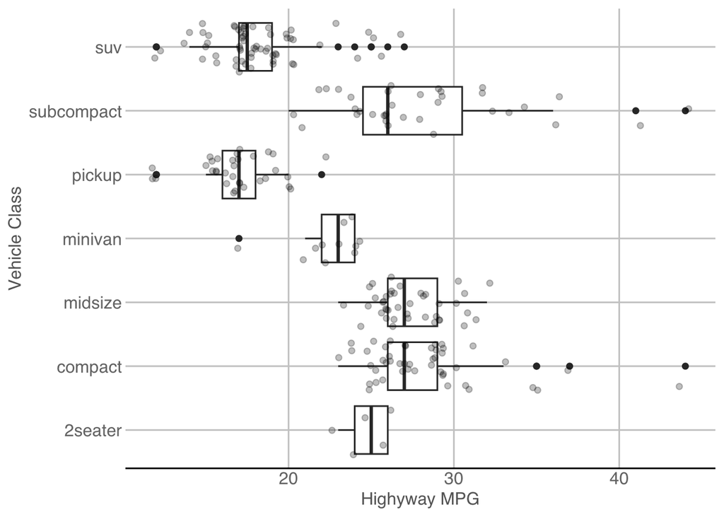

Why might your graph not match the example exactly? What could we do to ensure our graphs were identical?